# Math 421 - Midterm

## III. Predictive Models

Continue with the data from part I. Make sure you do not have any missing values in the data. Use the follows as the target and input variables:

```r
colSums(is.na(df1))
```

```
##      yod pay_ub92      age      sex  filler1  filler2 provider      moa
##        0        0        0        0   131478   131478        0        0
##      yoa      mod  filler3      dx1      dx2      dx3      dx4      dx5
##        0        0   131478        6      658     2995     9046    17097
##      dx6      dx7      px1      px2      px3      px4      px5      px6
##    25109    32911    60486    80619    96835   109573   115511   121065
##      px7      px8      px9     px10      los  filler4  service      icu
##   122544   125272   125741   127292        0   131478        0        0
##      ccu dispub92    payer      drg   trandb   randbg   randbs      orr
##        0        0        0        0        0        0        0        0
##     anes      seq      lab    dtest     ther    blood     phar    other
##        0        0        0        0        0        0        0        0
##   patcon  filler6    total      tot      dx8      dx9     dx10     dx11
##        0   131478        0        0    40355    47624    54443    61199
##     b_wt  ancilar   campus   er_fee  er_chrg obs_chrg psycchrg     dx12
##        0        0        0        0        0        0        0    67304
##     dx13     dx14     dx15     dx16     dx17     dx18     dx19     dx20
##    73152    78808    84159    89328    94019    98425   102439   106035
##     dx21     dx22     dx23     dx24     dx25     px11     px12     px13
##   109344   112219   114834   117112   119097   127497   128547   128640
##     px14     px15     px16     px17     px18     px19     px20     px21
##   129299   129342   129853   129880   130233   130265   130522   130538
##     px22     px23     px24     px25  filler7     race   ethnic     poa1
##   130725   130729   130877   130890   131478        9        0     6451
##     poa2     poa3     poa4     poa5     poa6     poa7     poa8     poa9
##     7699    12409    19531    26665    33952    41006    47899    54545
##    poa10    poa11    poa12    poa13    poa14    poa15    poa16    poa17
##    61049    67129    72909    78316    83713    88534    93259    97499
##    poa18    poa19    poa20    poa21    poa22    poa23    poa24    poa25
##   101637   105171   108438   111493   113923   116403   118453   120268
## ecodepoa  filler8 filler6a   season
##   131478        0   131478        0
```

```r
head(df1)
```

```
## # A tibble: 6 × 124
##     yod pay_ub92   age sex   filler1 filler2 provider moa   yoa     mod filler3
##   <dbl>    <dbl> <dbl> <fct> <lgl>   <lgl>   <fct>    <fct> <fct> <dbl> <lgl>
## 1    18        9     0 1     NA      NA      7214     1     18        1 NA
## 2    18        2    76 2     NA      NA      7214     1     18        1 NA
## 3    18        6    50 2     NA      NA      7214     12    17        1 NA
## 4    18        4     0 1     NA      NA      7214     1     18        1 NA
## 5    18       13     0 1     NA      NA      7214     12    17        1 NA
## 6    18        4     0 2     NA      NA      7214     12    17        1 NA
## # … with 113 more variables: dx1 <chr>, dx2 <chr>, dx3 <chr>, dx4 <chr>,
## #   dx5 <chr>, dx6 <chr>, dx7 <chr>, px1 <chr>, px2 <chr>, px3 <chr>,
## #   px4 <chr>, px5 <chr>, px6 <chr>, px7 <chr>, px8 <chr>, px9 <chr>,
## #   px10 <chr>, los <dbl>, filler4 <lgl>, service <chr>, icu <chr>, ccu <chr>,
## #   dispub92 <chr>, payer <chr>, drg <dbl>, trandb <chr>, randbg <chr>,
## #   randbs <chr>, orr <chr>, anes <chr>, seq <chr>, lab <chr>, dtest <chr>,
## #   ther <chr>, blood <chr>, phar <chr>, other <chr>, patcon <chr>, …
```

*Target Variable*: Create the target variable taking value of

- `low` if the total charge of a patient (`tot`) is smaller than the median of the total charge, and
- `high` otherwise.

```r
df1$target <- case_when(df1$tot < median(df1$tot) ~ 'low',

TRUE ~ 'high')
```

*Input Variables*:

- “age”,“sex”,“raceethn”,“provider”,“moa”,“mod”,“admtype”,“campus”, ‘los’

```r
df2 <- df1 %>% select('age','sex','provider','moa','mod',

'campus', 'los', 'target')
```

```r
head(df2)
```

```
## # A tibble: 6 × 8
##     age sex   provider moa     mod campus   los target
##   <dbl> <fct> <fct>    <fct> <dbl>  <dbl> <dbl> <chr>
## 1     0 1     7214     1         1      0     2 low
## 2    76 2     7214     1         1      0     1 high
## 3    50 2     7214     12        1      0     3 high
## 4     0 1     7214     1         1      0     4 low
## 5     0 1     7214     12        1      0    35 high
## 6     0 2     7214     12        1      0    17 high
```

1. Use `filter` function to filter out rows where `raceethn==''` or `admtype==''`. Make sure all the categorical variables are factor, numeric variables are numeric. Set Training : Testing Split = 10 : 90

```r
library(caret)

splitIndex <- createDataPartition(df2$target, p = .10,
                                  list = FALSE)

df_train <- df2[ splitIndex,]

df_test <- df2[-splitIndex,]
```

2. Train a decision tree using `rpart`. Plot the decision tree. Plot the variable importance ranked by the tree.

```r
library(rpart)

tree_model <- rpart(target ~ ., data = df_train,

control = rpart.control(maxdepth = 5))
```

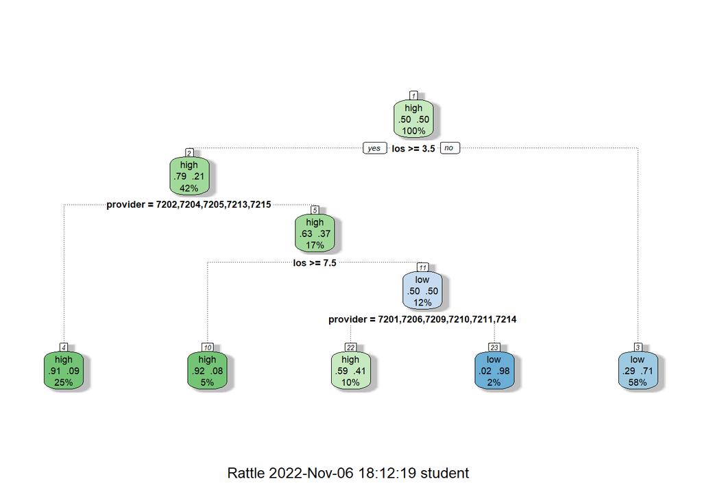

```r
library(rattle)

fancyRpartPlot(tree_model)
```

```r
tree_model$variable.importance
```

```
##        los   provider     campus        age
## 1845.15070  508.39241  151.83280   42.35668
```

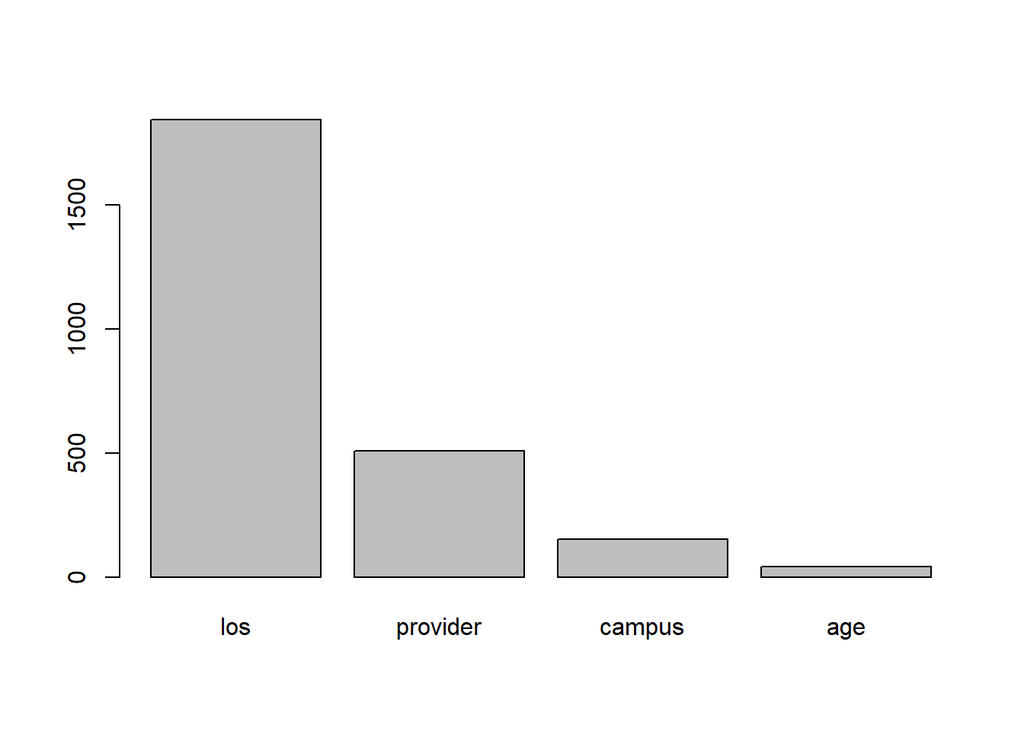

```r
barplot(tree_model$variable.importance)
```

3. Using caret for this question. Set `Training Control` to be: Use Cross-Validation of 5 folds across all models. Train & tune at least 2 different models (i.e. two different values for `method=` in the train function of caret). Plot the hyper-parameter tuning plots for each model.

```r
trControl = trainControl(method = "cv",

number = 5)

tuneGrid = expand.grid(mtry = 2:4,

splitrule = c('gini', 'extratrees'),

min.node.size = c(1:10))

forest_ranger <- train(target~., data=df_train,

method = "ranger",

trControl = trControl,

tuneGrid = tuneGrid)
```

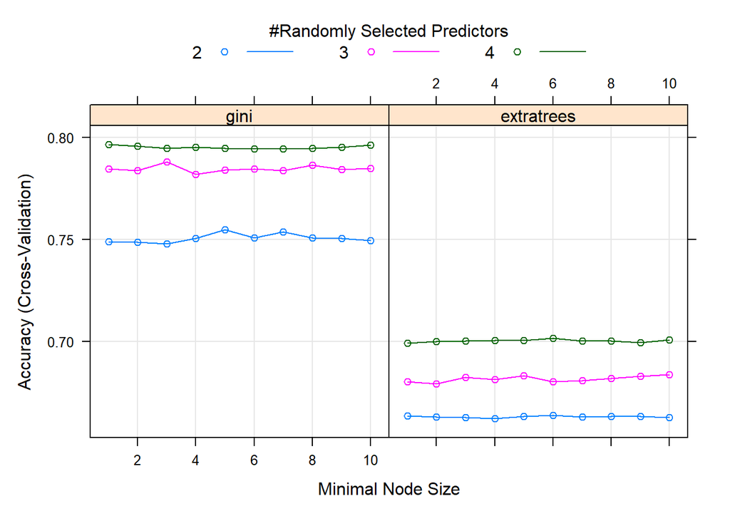

```r
plot(forest_ranger)
```

```r
df_test <- df_test %>%

mutate(target = as.factor(target))
```

```r
pred <- predict(forest_ranger, df_test)

cm <- confusionMatrix(data = pred, reference = df_test$target)

cm$overall[1]
```

```
##  Accuracy
## 0.7943192
```

```r
trControl = trainControl(method = "cv",

number = 5)

tuneGrid = expand.grid(predFixed = 2:5,

minNode = 10)

forest_Rborist <- train(target~., data=df_train,

method = "Rborist",

trControl = trControl,

tuneGrid = tuneGrid)
```

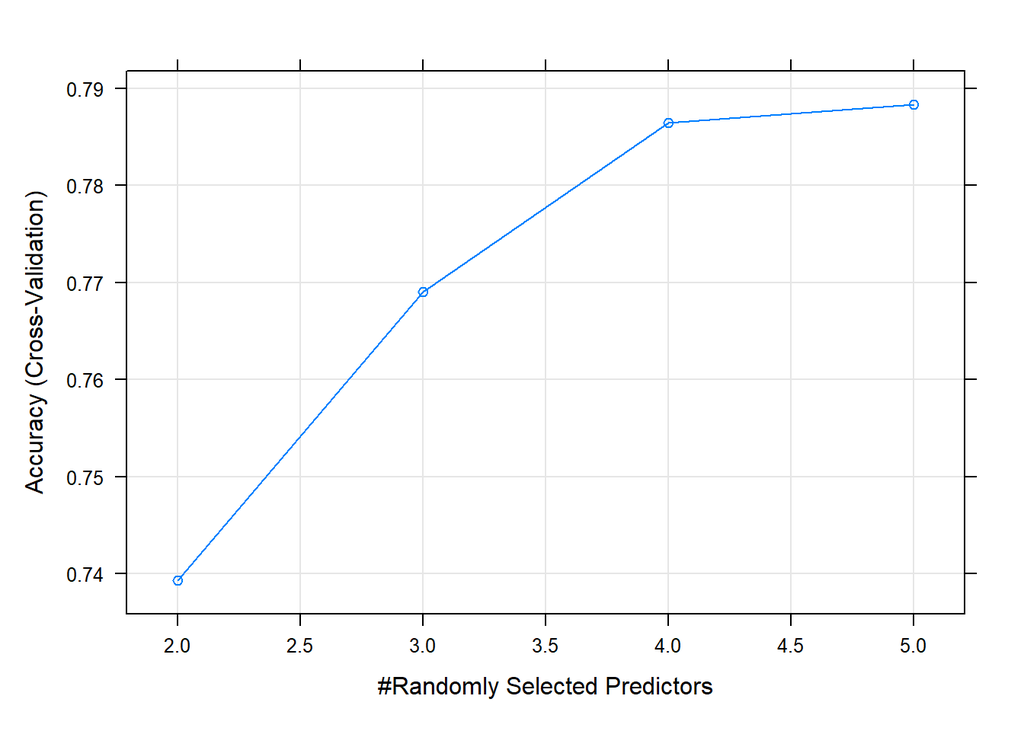

```r
plot(forest_Rborist)
```

```r
df_test <- df_test %>%

mutate(target = as.factor(target))
```

```r
pred <- predict(forest_Rborist, df_test)

cm <- confusionMatrix(data = pred, reference = df_test$target)

cm$overall[1]
```

```
##  Accuracy
## 0.7855133
```

4. Plot the comparison of the models in 3.

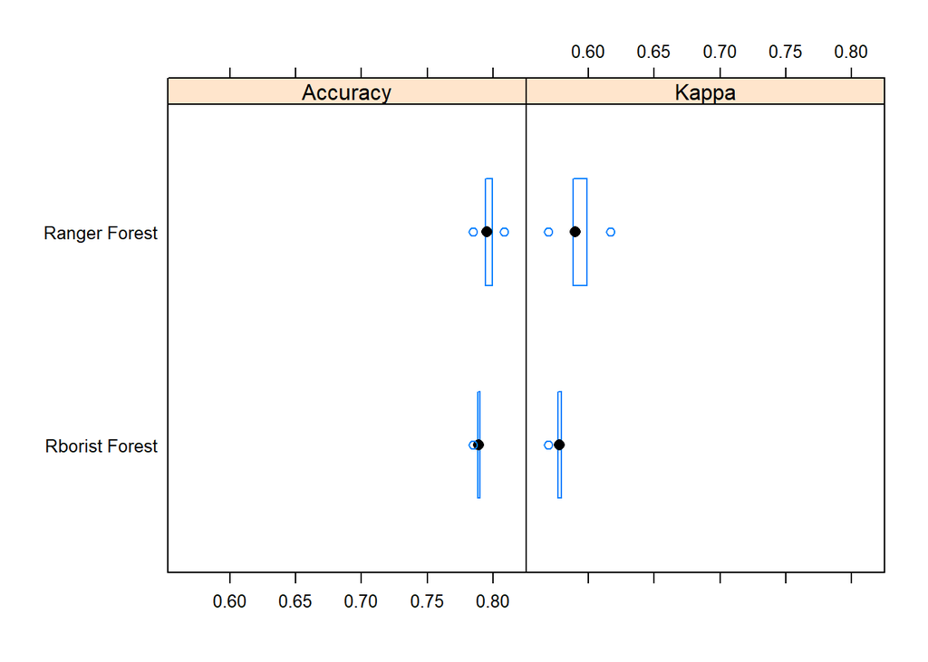

```r
results <- resamples(list('Ranger Forest' = forest_ranger,

'Rborist Forest' = forest_Rborist))

bwplot(results)
```

5. What is your final selection for the model? Test the accuracy of your final model on the test data.

```r
pred <- predict(forest_ranger, df_test)

cm <- confusionMatrix(data = pred, reference = df_test$target)

cm$overall[1]
```

```
##  Accuracy
## 0.7943192
```

6. Create another `target` variable (binary), decide the input variables and redo 1 to 5.

```r
df1$target <- case_when(df1$los < median(df1$los) ~ 'low',

TRUE ~ 'high')
```

```r
df3 <- df1 %>% select('age','sex','provider','moa','mod',

'campus', 'tot', 'yoa', 'yod','target')
```

```r
library(caret)

splitIndex <- createDataPartition(df2$target, p = .10,
                                  list = FALSE)

df_train <- df2[ splitIndex,]

df_test <- df2[-splitIndex,]
```

```r
library(rpart)

tree_model <- rpart(target ~ ., data = df_train,

control = rpart.control(maxdepth = 5))
```

[figure not shown]

```r
library(rattle)

fancyRpartPlot(tree_model)
```

```r
tree_model$variable.importance
```

```
##        los   provider        age     campus
## 1800.88964  345.80791   33.39010   10.10673
```

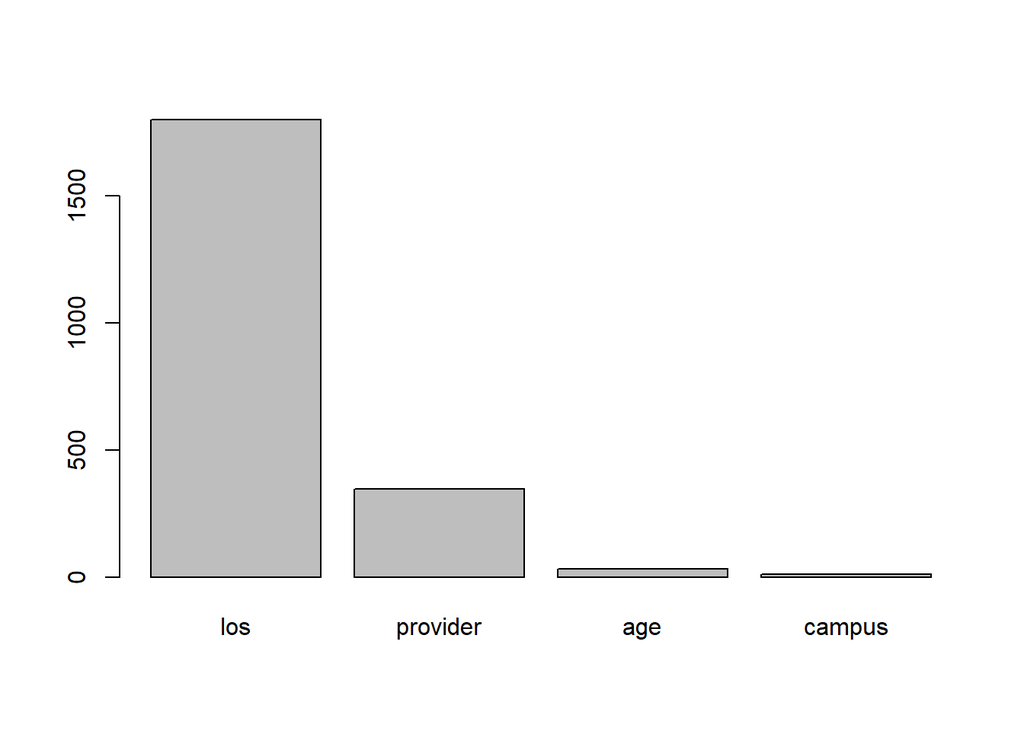

```r
barplot(tree_model$variable.importance)
```

```r
trControl = trainControl(method = "cv",

number = 5)

tuneGrid = expand.grid(mtry = 2:4,

splitrule = c('gini', 'extratrees'),

min.node.size = c(1:10))

forest_ranger <- train(target~., data=df_train,

method = "ranger",

trControl = trControl,

tuneGrid = tuneGrid)
```

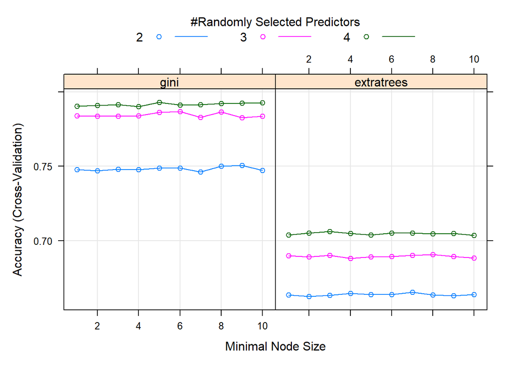

```r
plot(forest_ranger)
```

```r
df_test <- df_test %>%

mutate(target = as.factor(target))
```

```r
pred <- predict(forest_ranger, df_test)

cm <- confusionMatrix(data = pred, reference = df_test$target)

cm$overall[1]
```

```
##  Accuracy
## 0.7943446
```

```r
trControl = trainControl(method = "cv",

number = 5)

tuneGrid = expand.grid(predFixed = 2:5,

minNode = 10)

forest_Rborist <- train(target~., data=df_train,

method = "Rborist",

trControl = trControl,

tuneGrid = tuneGrid)
```

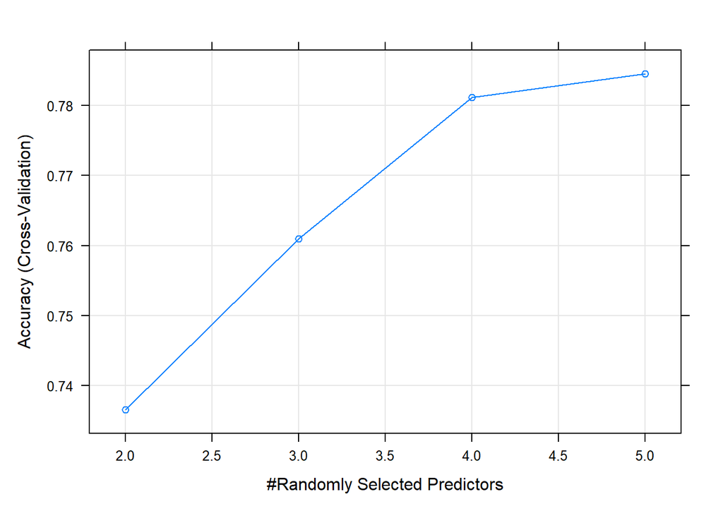

```r
plot(forest_Rborist)
```

```r
df_test <- df_test %>%

mutate(target = as.factor(target))
```

```r
pred <- predict(forest_Rborist, df_test)

cm <- confusionMatrix(data = pred, reference = df_test$target)

cm$overall[1]
```

```
##  Accuracy
## 0.7859443
```

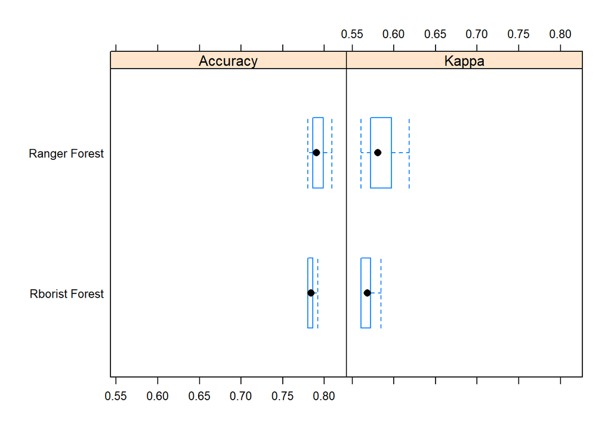

```r
results <- resamples(list('Ranger Forest' = forest_ranger,

'Rborist Forest' = forest_Rborist))

bwplot(results)
```

```r
pred <- predict(forest_ranger, df_test)

cm <- confusionMatrix(data = pred, reference = df_test$target)

cm$overall[1]
```

```
##  Accuracy
## 0.7943446
```

7. Write a paragraph to summarize the section and give your comments on the results.